# Using fastText to classify reddit submissions

## A quick and dirty tutorial

Will Radford - @wejradford

# fastText

Concerted programme of research from Facebook towards practical text classification. Three key papers from 2016:

- [Enriching Word Vectors with Subword Information](https://arxiv.org/abs/1607.04606)
- [Bag of Tricks for Efficient Text Classification](https://arxiv.org/abs/1607.01759)
- [FastText.zip: Compressing text classification models](https://arxiv.org/abs/1612.03651)

Open source at [GitHub](https://github.com/facebookresearch/fastText) and [elsewhere](https://fasttext.cc/)

# How does it work?

[figure not shown]

- Lowest layer maps n-grams to `d`-dimension word embeddings (à la word2vec) *smushed* together with averaging.
- Hidden layer maps each dimension to a weight.
- Top layer is the label.

# Mixing neural and shallow models

- Word embeddings for a **task-specific** representation
- Linear models for **fast** learning and prediction

$\rightarrow$ **Faster and hopefully better than bag-of-words**

# Dealing with large vocabulary

- Word n-grams give more context than words alone

  ```
  >>> tokens('the cat sat on the mat')
  ['the', 'cat', 'sat', 'on', 'the', 'mat']
  >>> ngrams('the cat sat on the mat')
  ['START_the', 'the_cat', 'cat_sat', 'sat_on', 'on_the', 'the_mat', 'mat_END']
  ```

- But:
  - Much sparser features (more zeros than non-zeros)
  - Need to maintain the mappings from `sat_on` to `feature_12345`, which costs memory and slows multicore learning
- *The hashing trick* (see also [vowpal wabbit](https://github.com/JohnLangford/vowpal_wabbit) maps n-grams into a constrained memory space

$\rightarrow$ **More memory-efficient and parallelisable learning**

# Classifying in large label spaces

- Linear classifiers run at $O(fk)$ where:
  - $f$ the number of features (i.e. dimensions)
  - $k$ is the number of labels
- Hierarchical softmax reduces this to $O(f\log_{2}k)$ by building a tree of labels arranged by probability.

$\rightarrow$ **Faster with some accuracy cost**

# Compressing models

- Large models limit the deployment environment and increase load time
- *Vector quantisation* lossily compresses the model

$\rightarrow$ **Smaller models at some accuracy cost**

# Handling unseen words

- Bag-of-words limits the model to handling those words seen in training (maybe not for hashing...).
- Learn **character** n-grams embeddings to handle morphology (e.g. "**mak**e", "**mak**ing", "**mak**o") and unknown words.
- Pre-initialising word embeddings with those learned from different corpora.

$\rightarrow$ **More robust models**

# A toy task

- Reddit submissions collected at http://files.pushshift.io/reddit/submissions/
- Downloadable as `json`
  - `title` The title of the submission
  - `subreddit` The subreddit it was submitted to

$\rightarrow$ Given the `title`, predict which `subreddit` it belongs to.

# Preprocessing

- Take each post
- Find the first sentence
- Apply a `really dumb tokeniser to split words !`
- Use the subreddit topic as the label

# Streaming through reddit submissions

- First 50K used to find the top-20 common labels (plus `other`), and for training embeddings
- Next 10K for training
- Next 10K for development
- Next 1K for test

# Training the model

- Wrap command-line `fastText` using some python
- Call and predict, returning:
  - Precision
  - Recall
  - F1
  - Training time
  - Model size

# Sanity-check baseline

- Using `scikit-learn`, nothing fancy
- Bag of words (unigrams and bigrams)
- Logistic regression prediction

# Data

```python
data_stats = pd.DataFrame([{'Label': k, 'Count': v} for k, v in
              Counter((i[0] for i in train)).items()]).sort_values('Count', ascending=False)
data_stats[:10]
```

|  | Count | Label |
| --- | --- | --- |
| 16 | 1700 | AutoNewspaper |
| 11 | 1248 | AskReddit |
| 1 | 1085 | GlobalOffensiveTrade |
| 6 | 740 | news |
| 4 | 691 | RocketLeagueExchange |
| 7 | 637 | newsbotbot |
| 17 | 473 | The_Donald |
| 5 | 472 | business |
| 15 | 459 | videos |
| 8 | 389 | Showerthoughts |

```python
data_stats[10:]
```

|  | Count | Label |
| --- | --- | --- |
| 2 | 349 | funny |
| 3 | 278 | me_irl |
| 9 | 272 | gameofthrones |
| 14 | 262 | gaming |
| 13 | 225 | aww |
| 10 | 207 | pics |
| 18 | 172 | Overwatch |
| 19 | 151 | MemezForDayz |
| 12 | 140 | gonewild |
| 20 | 49 | Ice_Poseidon |
| 0 | 1 | ShittyCarMod |

```python
data_df = pd.DataFrame([{'Text': t, 'Label': l} for l, t in train[:10]])
data_df
```

|  | Label | Text |
| --- | --- | --- |
| 0 | ShittyCarMod | Maserati with an Aerodynamic Spoiler |
| 1 | GlobalOffensiveTrade | [Store] Double moses M9 #355, Dual side blue g... |
| 2 | funny | Adam Mišík – Tak pojď |
| 3 | me_irl | me 🌞irl |
| 4 | RocketLeagueExchange | [ps4] [h] crimsom mantis [w] offers key prefer |
| 5 | business | Edible Prints on Cake |
| 6 | funny | RT @naukhaizs: #pakistan #karachi #lahore #isl... |
| 7 | news | 10 ảnh avatar buồn , thất tình , tâm trạng dàn... |
| 8 | newsbotbot | @washingtonpost: For Facebook , erasing hate s... |
| 9 | Showerthoughts | Russia vs USA |

# Results

Comparing models trained on `train`, hyperparameters tuned on `development` and evaluated on `test`:

- `baseline` model with L2 regularisation, C10
- `fastText` model with epoch 90, dimensions=50
- `fastText-quantized` model as above but quantized

```python
df
```

|  | name | time | size | p | r | f |
| --- | --- | --- | --- | --- | --- | --- |
| 0 | baseline | 21.397510 | 176.164019 | 0.692 | 0.692 | 0.692 |
| 1 | fastText | 6.789109 | 64.886967 | 0.689 | 0.689 | 0.689 |
| 2 | fastText-quantized | 54.206348 | 3.623718 | 0.702 | 0.702 | 0.702 |

# Size vs Time

- Left-to-right: `baseline`, `fastText`, `fastText-quantized`
- `fastText` smaller and quicker to train than `baseline`
- `fastText-quantized` smaller again, but much slower to train

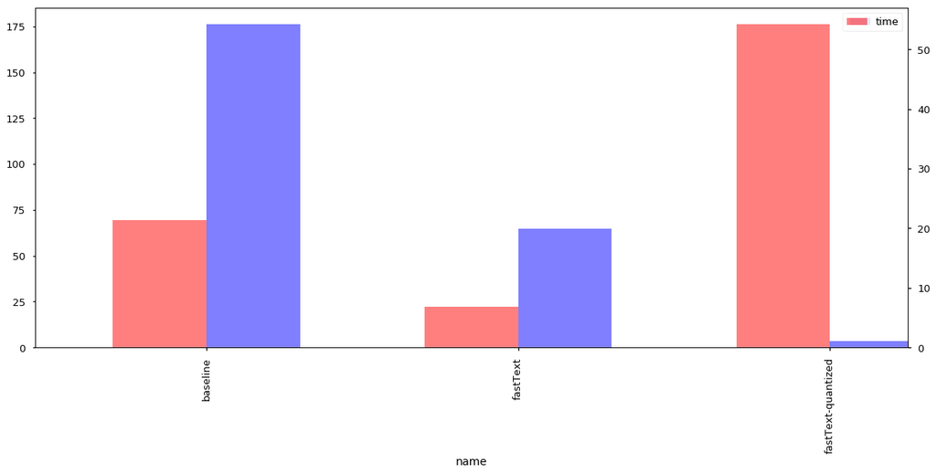

```python
plot(df)
```

# Performance

- very similar performance
- quantisation makes little impact on F1 score

$\rightarrow$ **significant difference, probably not...**

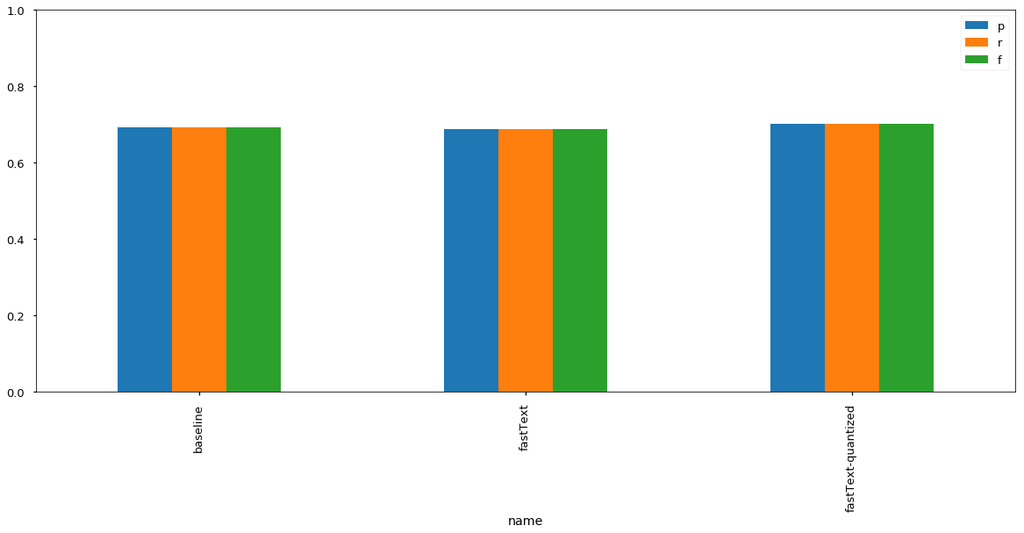

```python
df.plot(kind='bar', x='name', y=['p', 'r', 'f'], ylim=(0, 1), figsize=(20, 8))
```

# What I didn't look at here

- Sub-word embeddings for performance on unknown words.
- Not using hierarchical softmax to give slower, but better models.
- Pre-initialising with other word embeddings.

# Conclusions

`fastText` is worth trying.

- Works relatively well for text (see also `*Sem` "embed all the things")
- Can have small model sizes (for mobile or serverless platforms)
- Trains quickly enough to tune and spend time getting more data